# Introduction to BASH

Specialist module CINS0028: Multi-omics and Cancer Evolution

Dr A M Mahedi Hasan

23-01-2025

### Preface

This is an introduction to BASH (Bourne Again SHell). Please don’t take the word literally, nor with a hint of the sequel of the spy movie in the realm of Bourne. Well, its very basic to begin with, but if you want to delve deep into BASH (or Shell language) and perform complex operations, you can do so. But we will stick to the basics for now.

One thing to remember is that BASH is a scripting language, and it is used to automate tasks. It is a command language interpreter that executes commands read from the standard input or from a file. BASH also incorporates useful features from the Korn and C shells (ksh and csh). What the hell are those things? Well, they are other shell languages and I will mention those to the lecture class. Sometimes it’s hard to distinguish the basic linux commands from the shell commands. To my view, they are the same to begin with, but the intricacies of BASH (or Shell scripting) comes later.

I hope, by now you all know about the basic linux commands like `ls, echo, cat, head, grep` etc. So, let’s start with the basics of BASH scripting. The most important aspect of a bash script (to my view of course) is, instead of executing your commands separately, you can accommodate all thes in a single file and execute it serially with a sungle command (*i.e.* running the BASH script).

### BASH Scripting

```bash
which bash
```

```bash
#!/bin/bash
echo 'my first bash script'
```

Once your script is written you can save it and run it. The file extension is usually `.sh`. Though this is just a convention if you have the first line with the shebang, you can run the script without the `.sh` extension. You basically run the script using the command:

```bash
bash my_first_script.sh
```

Or you can make the script executable and run it using the command:

```bash
chmod +x my_first_script.sh
./my_first_script.sh
```

Each line of a Bash script can be a shell command. The shell command can be a system command, a user-defined function, or a script. The shell command can be a simple command or a compound command (pipped). You are be able to write a chain of commands piped (I assume you know what a pipe is and how to use it by now) into each other in the terminal.

### Standard streams

Before going further down to more nitty-gritty of BASH scripting, let’s learn a bit about inputs and outputs for your Bash scripts.

In BASH, there are three standard streams: `stdin`, `stdout`, and `stderr`.

`stdin` is the standard input stream of data (or information) going into the program, `stdout` is the standard output stream, and `stderr` is the standard error stream where errors and exceptions in the program are written to. The standard streams are connected to the terminal by default.

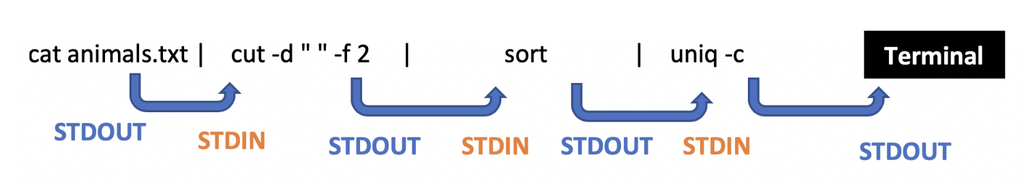

This graphical example represents what we just discussed conceptually. The standard output of the `cat` command, becomes the standard input for the `cut` command and so on until the pipe finishes which prints the last standard output to the terminal. This is the expected behaviour. Though if an error occurred at any time, the error would by default display in the terminal.

The standard streams can be redirected to files or other programs using the redirection operators: Using >1 at the end of a command and add a file name thereafter will redirect the standard output to a file. For example, `ls > file.txt` will redirect the output of the `ls` command to a file called `file.txt`. Using 2> at the end of a command and add a file name thereafter will redirect the standard error to a file. For example, `ls 2> file.txt` will redirect the error output of the `ls` command to a file called `file.txt`.

### Arguments

Another key concept for Bash scripting is the use of arguments. Bash scripts take arguments specified when making the execution call of the script. `ARGV` is a term to describe all the arguments that are fed into the script.

You can access the arguments using numerical dollar-sign notation `$`. The first argument being `$1` and so on. Some other special arguments are `$@` and `$*` which return all the arguments together. `$#` gives the number of arguments. Let’s see an example of a script that takes arguments (save it as my_ARGV_script.sh).

```bash
#!/bin/bash
echo "The first argument is $1"
echo "The second argument is $2"

echo "All the arguments are $@"
echo "All the arguments are $*"

echo "The number of arguments is $#"
```

Now run `bash my_ARGV_script.sh arg1 arg2 arg3 arg4` and see the output.

### Variables in BASH

#### Basic Variables

Variables in BASH are defined by the user and can be used to store data. The syntax for defining a variable is `variable_name=value`. A very important information for you to remember (I would suggest you hard code it in your brain): there should be no gaps before or after the equal sign while assigning a value to a variable (in Bash). The value can be a string, number, or any other data type. The value can be accessed using the dollar sign `$` followed by the variable name. Let’s see an example:

```bash
#!/bin/bash

first_name_var="Mahedi"
last_name_var="Hasan"

echo "my name is" $first_name_var $last_name_var
```

You can name the variables as you like and it is good practice to name them something which makes sense. Remember that the `$` sign is very important, otherwise the interpreter will not understand that you are referencing to a variable, rather it will think it as any other character string for echoing (not sure that’s a verb, like google …).

In BASH, using different types of quotation marks can mean different things, when creating variables and printing. Single quotation marks means that whatever is between them is interpreted literally. Double quotation is similar to single quotation marks, but it will understand dollar-sign notation and backticks that occur between the quotation marks. Backticks creates a shell within a shell. That is, it sends whatever is between the backticks out to a new shell and takes the results back into the variable. Let’s see with an example:

```bash
#!/bin/bash

first_name_var="Mahedi"
last_name_var="Hasan"

echo 'my name is $first_name_var $last_name_var'
echo "my name is $first_name_var $last_name_var"

# date is a function that print the current date

echo "Today is `date`"

# or

echo "Today is $(date)"
```

By the way, you find that I put comments starting with a hash `#` sign. This is a good practice to comment your code. It helps you to understand what you did when you come back to your code after a long time (or sometime, the next day).

#### Numeric Variables and Arithmetic Operations

Though arithmetic operation is not the main focus of BASH scripting, you can still perform arithmetic operations in BASH. To begin with, you cannot natively do arithmetic in Bash, like - `1 + 1` (like you do in R consol). If you try the following in the Bash terminal, you will get an error like this. `-bash: 1: command not found`.

I will discuss two ways to perform arithmetic operations in BASH:

1. Using `expr` command: You can use the `expr` command to perform arithmetic operations. The `expr` command evaluates an expression and writes the result on the standard output. The expression may be a simple arithmetic operation of the form:

```bash
expr 1 + 1

# an alternative way to do the same thing

expr $(( 1 + 1))
```

2. Using `bc` (basic calculator) command: The `bc` command is a command-line calculator. It is used to perform simple arithmetic operations. The `bc` command can handle decimal places. The following example shows how to use the `bc` command:

```bash
echo "1.1 + 1.1" | bc

# you can use the scale option to specify the number of decimal places

echo "scale=3; (1.1 + 1.1)/3" | bc
```

We can generate two numeric variables and perform arithmetic operations on them and print the result out. Let’s see an example:

```bash
#!/bin/bash

num1=10
num2=20

echo "The sum of $num1 and $num2 is $(echo "$num1 + $num2" | bc)" # this is another example shell-within-shell
echo "The difference of $num1 and $num2 is $(echo "$num1 - $num2" | bc)"
echo "The product of $num1 and $num2 is $(echo "$num1 * $num2" | bc)"
echo "The division of $num1 and $num2 is $(echo "scale=3;$num1 / $num2" | bc)"
```

### Arrays in BASH

So far, I have discussed (a bit) single value under a variable. However, if you have to deal with more than one value, you can use arrays. This is similar to vector in `R` or list in `python`. An array is a variable that can store multiple values. The values are stored in the array with a space between them (contrary to comma separated values in `R`).

There are two types of arrays in BASH: *indexed arrays* and *associative arrays*. In this lecture, I will discuss indexed arrays. An indexed array is an array in which the keys are represented by integers. The syntax for defining an indexed array is `array_name=(value1 value2 value3)`. The values can be accessed using the index of the array. The index of the array starts from 0 (thus called a zero-indexing system). Let’s see an example:

```bash
#!/bin/bash

# declare an empty array
declare -a fruits

# defining an array
declare -a fruits=("apple" "banana" "orange" "grape")

# or directly
fruits=("apple" "banana" "orange" "grape")

# accessing the values
echo ${fruits[0]}
echo ${fruits[1]}

# accessing a range of values
echo ${fruits[@]:1:2}

# accessing all the values
echo ${fruits[@]}
echo ${fruits[*]}

# accessing the length of the array
echo ${#fruits[@]}
echo ${#fruits[*]}

# accessing the length of a specific element
echo ${#fruits[0]}

# adding a new element
fruits[4]="mango" # don't use $ in the front of the index

# removing an element
unset fruits[2]
```

### Conditional Statements in BASH

Conditional statements are used to perform different actions based on different conditions. The syntax for a basic `IF` conditional statement is:

```bash
if [ condition ]
then
    statement
fi

# to extend with an else statement:

if [ condition ]
then
    statement
else
    statement
fi
```

The `if` statement is followed by a condition in square brackets. The `then` keyword is used to start the block of code that will be executed if the condition is true. The `fi` keyword is used to end the block of code. The condition can be a comparison between two values, a file test, or a string test. The comparison operators are:

- `-eq` : equal
- `-ne` : not equal
- `-gt` : greater than
- `-lt` : less than
- `-ge` : greater than or equal to
- `-le` : less than or equal to

The following example shows how to use the `if` statement:

```bash
#!/bin/bash

num1=10
num2=20

if [ $num1 -eq $num2 ]
then
    echo "The numbers are equal"
else
    echo "The numbers are not equal"
fi
```

You can also use the `elif` keyword to add more conditions to the `if` statement. The `elif` keyword is used to add more conditions to the `if` statement. The following example shows how to use the `elif` statement:

```bash
#!/bin/bash

num1=10
num2=20

if [ $num1 -eq $num2 ]
then
    echo "The numbers are equal"
elif [ $num1 -gt $num2 ]
then
    echo "The first number is greater than the second number"
else
    echo "The first number is less than the second number"
fi
```

You cad add multiple conditions using the `&&` (also `AND`) and `||` (also `OR`) operators. The `&&` operator is used to execute the second command if the first command is true. The `||` operator is used to execute the second command if the first command is false. The following example shows how to use the `&&` and `||` operators:

```bash
#!/bin/bash

num1=10
num2=20

if [ $num1 -eq $num2 ] && [ $num1 -gt 5 ]
then
    echo "The numbers are equal and the first number is greater than 5"
fi

# with OR

if [ $num1 -eq $num2 ] || [ $num1 -gt 5 ]
then
    echo "The numbers are equal or the first number is greater than 5"
fi
```

### Loops in BASH: for loop and while statements

Loops are used to execute a block of code multiple times. There are three types of loops in BASH: `for` loop, `while` loop (or some says it statement), and `until` loop. I will stick to the first two.

The `for` loop is used to iterate over a list of items. The syntax for a basic `for` loop is:

```bash
for item in list
do
    statement
done
```

The `for` loop is followed by the `item` keyword, the `in` keyword, and a list of items. The `do` keyword is used to start the block of code that will be executed for each item in the list. The `done` keyword is used to end the block of code. The list of items can be a range of numbers, a list of strings, or the values of an array. The following example shows how to use the `for` loop:

```bash
#!/bin/bash

# iterating over a range of numbers
for i in {1..5..2} # this is an interesting way to generate a range of numbers
do
    echo $i
done

# iterating over a list of strings
for fruit in apple banana orange grape
do
    echo $fruit
done

# iterating over the values of an array
fruits=("apple" "banana" "orange" "grape")
for fruit in ${fruits[@]}
do
    echo $fruit
done

# I frequently use the for loop to iterate over the files in a directory

for file in /path/to/directory/*.txt
do
    echo $file
done
```

The `while` loop is used to execute a block of code as long as a condition is true. The syntax for a basic `while` loop is:

```bash
while [ condition ]
do
    statement
done
```

The `while` loop is followed by a condition (in square brackets, here, contracy to a set of items to iterate over). The `do` keyword is used to start the block of code that will be executed as long as the condition is true. The `done` keyword is used to end the block of code. The condition can be a comparison between two values, a file test, or a string test. The following example shows how to use the `while` loop:

```bash
#!/bin/bash

i=1

while [ $i -le 5 ]
do
    echo $i
    i=$((i+1))
done
```

But, be aware of infinite loops. An infinite loop is a loop that will run forever. The following example shows how to create an infinite loop:

```bash
#!/bin/bash

while true
do
    echo "This is an infinite loop"
done
```

### Functions in BASH

Functions are a core part of most programming languages. If you have used them in R or Python you will know some of these advantages. Firstly, functions allow a reusable section of code that reduces repetition. Therefore you can make neat, compartmentalized code. That is, the code is modular so you can work on, add or subtract different sections as needed. Finally, functions allow for easy sharing of code. If you know what the function’s purpose, the inputs and outputs are then you can use it.

Functions are used to group a set of commands together to perform a specific task. The syntax for defining a function is:

```bash
function_name () {
    statement
}
```

You start by writing a name for your function. The `function_name` is the name of the function. Make sure it is a sensible name that makes sense. This enhances code readability. The `()` is used to define the function. Then add curly brackets (or braces). The `statement` is the block of code that will be executed when the function is called. Inside here place the code to run when the function is called. You can use anything you learned so far such as loops, IF statements, calling shell-within-a-shell constructs and more. You can optionally return something. The following example shows how to define a function:

```bash
#!/bin/bash

# defining a function

print_name () {
    echo "My name is Mahedi Hasan"
}

# calling the function

print_name


# passing arguments to a function

print_name () {
    echo "My name is $1 $2"
}

print_name Mahedi Hasan

# returning a value from a function

add_numbers () {
    echo $(($1 + $2))
}

result=$(add_numbers 10 20)

echo $result
```

### File Operations in BASH

You can perform file operations in BASH. The following example shows how to check if a file exists, if a file is readable, writable, or executable, and how to create a file:

```bash
#!/bin/bash

# check if a file exists

if [ -e file.txt ]
then
    echo "The file exists"
else
    echo "The file does not exist"
fi

# check if a file is readable

if [ -r file.txt ]
then
    echo "The file is readable"
else
    echo "The file is not readable"
fi

# check if a file is writable

if [ -w file.txt ]
then
    echo "The file is writable"
else
    echo "The file is not writable"
fi

# check if a file is executable

if [ -x file.txt ]
then
    echo "The file is executable"
else
    echo "The file is not executable"
fi

# create a file

touch new_file.txt

# remove a file

rm new_file.txt
```

### Task scheduling in BASH

There are many situations where being able to schedule scripts is helpful. Firstly, you may have regular tasks to be done. Such as daily, weekly or multiple times per day. You could try to remind yourself - but what if you forget or are away? Secondly, you can better use resources. Such as running scripts early in the morning when server usage is low. Learning to schedule with cron is an essential skill in modern data infrastructures.

The program ‘cron’ has been part of unix-like systems for a long time. Since the 70’s in fact. We humans have been lazy for that long! The name comes from the Greek word for time, chronos. Cron is a time-based job scheduler in Unix-like operating systems. Cron is driven by a crontab (cron table) file, a configuration file that specifies shell commands to run periodically on a given schedule. The crontab files are stored where the lists of jobs and other instructions to the cron daemon are kept. Users can have their own individual crontab files and often there is a system-wide crontab file (usually in /etc or a subdirectory of /etc) that only system administrators can edit.

The following example shows how to schedule a BASH script using cron:

```bash
#!/bin/bash

# create a BASH script

echo "echo 'Hello World'" > hello_world.sh

# make the script executable

chmod +x hello_world.sh

# open the crontab file

crontab -e

# add the following line to the crontab file

5 1 * * * /path/to/hello_world.sh

15 14 * * 7 /path/to/hello_world.sh

# save and exit the crontab file
```

Let’s walk through some example cronjobs. There are minutes, hours, days of the month, months of the year and days of the week. The default (just a star) means to run at every interval. In the first example. The minutes star is 5 (meaning 5 minutes past the hour). Which hour? Well, the hours star is 1 (meaning after 1am). The last three are all stars, meaning ‘every’. So overall, we run myscript.sh every day at 1:05am.

In this second example. The minutes star is 15 (meaning 15 minutes past the hour), the hours star is 14 (meaning after 2pm). The stars for day-of-month and month-of-year are ‘every’. The last star is day 7 (on Sundays). So overall we run myscript.sh at 2:15pm every Sunday.

### Conclusion

This is a very basic introduction to BASH scripting. There are many more things you can do with BASH scripting. You can use BASH scripting to automate tasks, perform complex operations, and more. I hope this introduction has given you a good starting point for learning BASH scripting. If you have any questions, feel free to ask. I will be happy to help. Thank you for reading.